# HW 4

### We will read in the data and combine both files into one dataframe

```python
import pandas as pd

data = pd.DataFrame(columns = ['V','Text'])
file_paths = [r'C:\Users\Javy\Downloads\TrainingDataNegative.txt',r'C:\Users\Javy\Downloads\TrainingDataPositive.txt']
v = 0
for i in file_paths:

    with open(i) as f:


        file = f.readlines()

        for rev in file:
            data = data.append(pd.DataFrame({'V':v, 'Text': rev}, index = [0]))

    data = data.append(pd.DataFrame({'V':v, 'Text': rev}, index = [0]))
    v += 1
```

### Now we can preprocess the data

```python
import re
import nltk
from nltk.corpus import stopwords
nltk.download('words')
nltk.download('stopwords')
all_stop = stopwords.words('english')
real_words = set(nltk.corpus.words.words())


df = data[~data.duplicated()]
df.reset_index(inplace = True)
df['Text'] = df['Text'].apply(str.lower)
df['Text'] = df['Text'].str.replace('[.!,@%]',"")
```

```python
def remove_stops(line):
    temp = line.split()
    words = [lemma for lemma in temp if lemma not in all_stop
            ]
    return " ".join(words)

def remove_fake(line):
    temp = line.split()

    return " ".join(w for w in nltk.wordpunct_tokenize(line) \
         if w.lower()  in real_words)


df['Text'] = df['Text'].apply(remove_stops)
df['Text'] = df['Text'].apply(remove_fake)
```

### Now we can create our model

```python
from sklearn.naive_bayes import MultinomialNB
from sklearn.model_selection import train_test_split
from sklearn.feature_extraction.text import TfidfTransformer
from sklearn.feature_extraction.text import CountVectorizer
import numpy as np
X_train = df['Text']
```

```python
vect = CountVectorizer()
vect.fit(X_train)
simple_train_dtm = vect.transform(X_train)
x = pd.DataFrame(simple_train_dtm.toarray(), columns=vect.get_feature_names())
```

```python
y_train = df.V.astype('int')
y_train
nb = MultinomialNB()
%time nb.fit(simple_train_dtm,  y_train)
```

```
Wall time: 8 ms
```

```
MultinomialNB()
```

### Now we can import the test dataset and preprocess it

```python
testdf = pd.DataFrame(columns = ['V','Text'])
file_paths = [r'C:\Users\Javy\Downloads\testSet.txt']
v = 0
for i in file_paths:

    with open(i) as f:
        file = f.readlines()


        for rev in file:
            testdf = testdf.append(pd.DataFrame({'V':v, 'Text': rev}, index = [0]))
testdf.reset_index(inplace = True)
testdf.iloc[:2989, 1] = 1
testdf = testdf.iloc[:,1:]
```

```python
testdf['Text'] = testdf['Text'].apply(str.lower)
testdf['Text'] = testdf['Text'].str.replace('[.!,@%]',"")
testdf['Text'] = testdf['Text'].apply(remove_stops)
testdf['Text'] = testdf['Text'].apply(remove_fake)
```

```python
simple_test_dtm = vect.transform(testdf['Text'])
x_test = pd.DataFrame(simple_test_dtm.toarray(), columns=vect.get_feature_names())
```

```python
y_pred_class = nb.predict(simple_test_dtm)

from sklearn import metrics


y_test = np.array(testdf.V.astype(int)).flatten()
y_pred_class
metrics.accuracy_score(y_test, y_pred_class)
```

```
0.935894468872946
```

```python
metrics.confusion_matrix(y_test, y_pred_class)
```

```
array([[1186,  146],
       [ 131, 2858]], dtype=int64)
```

```python
#False positives
fp = testdf[y_test < y_pred_class]
fp
```

|  | V | Text |
| --- | --- | --- |
| 2995 | 0 | place stay business never good shopping experi... |
| 3004 | 0 | foundation theory stay business despite realit... |
| 3013 | 0 | i m huge fan moving area find different one al... |
| 3016 | 0 | mid century furniture supposed warm welcoming ... |
| 3020 | 0 | total joke place smoke even want play pool dea... |
| ... | ... | ... |
| 4281 | 0 | i m wedding san i information times mother cal... |
| 4287 | 0 | visit comedy spot ago night friend gabi s week... |
| 4302 | 0 | show definitely used looking stand up comedy i... |
| 4315 | 0 | wife late early find particularly funny talent... |
| 4317 | 0 | show ever seen never would boring stupidity we... |

146 rows × 2 columns

```python
# false negatives
fn = testdf[y_test > y_pred_class]
fn
```

|  | V | Text |
| --- | --- | --- |
| 12 | 1 | i m still laughing reading poor s review below... |
| 34 | 1 | cool people working coming never get tired get... |
| 36 | 1 | i m giving place i got long story behind make ... |
| 50 | 1 | come want really really expensive vodka end un... |
| 74 | 1 | alright bunch booze go home would probably end... |
| ... | ... | ... |
| 2894 | 1 | one fun night went birthday ended costing us h... |
| 2922 | 1 | saved day custom ordered ham another place tot... |
| 2931 | 1 | never buy type sausage giant eagle know real s... |
| 2942 | 1 | pepper steak get one understand nearly enough ... |
| 2967 | 1 | bring wallet little self control maybe better ... |

131 rows × 2 columns

### We can see what the most common words are in the false negative an false positive

```python
import matplotlib.pyplot as plt
vect.fit(fn['Text'])
fn_dtm = vect.transform(fn['Text'])
fn_df = pd.DataFrame(fn_dtm.toarray(), columns=vect.get_feature_names())
top_fn_words = pd.DataFrame(fn_df.sum().sort_values(ascending = False))
top_fn_words.iloc[:10]
```

|  | 0 |
| --- | --- |
| like | 71 |
| one | 71 |
| time | 69 |
| get | 69 |
| would | 69 |
| place | 59 |
| back | 52 |
| got | 51 |
| really | 50 |
| go | 48 |

```python
fp_dtm = vect.transform(fp['Text'])
fp_df = pd.DataFrame(fp_dtm.toarray(), columns=vect.get_feature_names())
top_fp_words = pd.DataFrame(fp_df.sum().sort_values(ascending = False))
top_fp_words.iloc[:10]
```

|  | 0 |
| --- | --- |
| place | 96 |
| one | 53 |
| like | 48 |
| good | 44 |
| go | 32 |
| food | 32 |
| would | 31 |
| time | 31 |
| get | 30 |
| see | 30 |

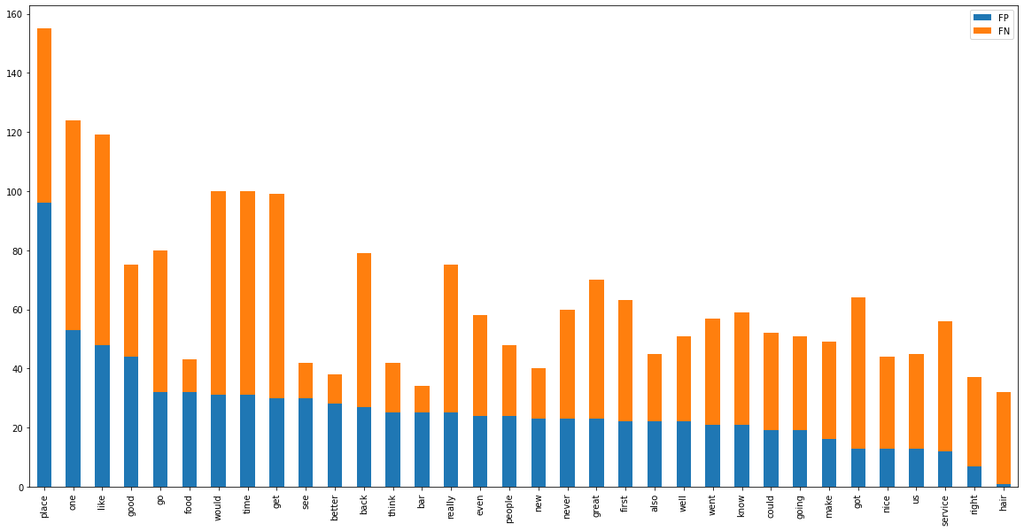

```python
top_fp_words['FN'] = top_fn_words
top_fp_words.columns = ['FP','FN']
index = top_fn_words.iloc[:25].index
index = index.append(top_fp_words.iloc[:25].index)
top_25 = top_fp_words[top_fp_words.index.isin(index)]
top_25.plot.bar(stacked=True, figsize = (20,10))
```

```python
# calculate AUC
y_pred_prob = nb.predict_proba(simple_test_dtm)[:, 1]
metrics.roc_auc_score(y_test, y_pred_prob)
```

```
0.9719189329845067
```

We began by importing the data, seperating the jumbled text, and appending it to a dataframe. We managed to utilize a little for loop to reduce code.

We then went to preprocess and prep the data. We first started by downloading a list of stopwords and common english words. We then converted all text to lowercase and removed several symbols. We then created functions to remove stop words and 'fake' words.

It was then time to create our model. We imported several libraries and fit our training data to a count vectorizer. we then transformed the data and created a data frame of the words and their frequency per review. We then converted our Classifier into integers, created our Multinomial Naive Bayes model, and fit the data.

It was then time to work on the test dataset. We repeated many of the steps above: import, preprocess, and transform. We were finally ready to predict our model and managed to get an accuracy of 93.59 percent! We also only had 131 false negatives and 146 false positives. I created a df showing both false positives and false negatives.

I then delve into these dataframes to evaluate the content. I displayed a list for the top ten FP words and top ten FN words and included their frequency. I then created a stacked bar-graph of the top 25 words in both the FP and FN list to show how their frequency differs. And lastly, calculated the roc-auc score just to confidently see if the model was good enough.